# Run-Length Encoding

Pour soumettre une image à une compétition Kaggle on est obligé de fournir la vérité terrain dans un fichier CSV, donc pas adapté à une image. Aussi on encode nos images, tout en les compressant, dans un format texte.

Je pars du principe que vous avez une archive Numpy qui contient la segmentation des 12 cerveaux de test. Regardez ci-dessous le format attendu.

```python
import numpy as np
import pandas as pd

import matplotlib.pylab as plt
```

```python
data_name = "brain_OR"
```

```python
brain = np.load(data_name+".npz")
```

```python
brain.files
```

```
['subject-11',
 'subject-12',
 'subject-13',
 'subject-14',
 'subject-15',
 'subject-16',
 'subject-17',
 'subject-18',
 'subject-19',
 'subject-20',
 'subject-21',
 'subject-22',
 'subject-23']
```

```python
for b in brain.files:
    print(brain[b].shape, brain[b].dtype)
```

```
(144, 192, 256, 4) bool
(144, 192, 256, 4) bool
(144, 192, 256, 4) bool
(144, 192, 256, 4) bool
(144, 192, 256, 4) bool
(144, 192, 256, 4) bool
(144, 192, 256, 4) bool
(144, 192, 256, 4) bool
(144, 192, 256, 4) bool
(144, 192, 256, 4) bool
(144, 192, 256, 4) bool
(144, 192, 256, 4) bool
(160, 192, 256, 4) bool
```

```python
def plot_slice(subject, indice, axis):
    res = brain[f"subject-{subject}"].take(indice, axis=axis)
    fig, ax = plt.subplots(1, 2, figsize=(16,10))
    ax[0].imshow(50*res[:,:,1]+150*res[:,:,2]+250*res[:,:,3])
    ax[0].set_title("Comb. linéaire")
    image_seuil = 1*res[:,:,0]+50*res[:,:,1]+150*res[:,:,2]+250*res[:,:,3]
    if (image_seuil == 0).sum() > 0:
        print("Nombre de pixels non déterminés par le seuil :", (image_seuil == 0).sum())
    ax[1].imshow(image_seuil)
    ax[1].set_title("Seuils")
```

```
Nombre de pixels non déterminés par le seuil : 4
```

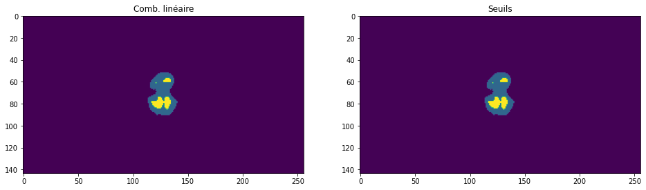

```python
plot_slice(14, 30,1)
```

```python
def rle_encoding(mask):
    pixels = mask.flatten()
    pixels = np.concatenate([[0], pixels, [0]])  # Ajout de 0 en début et fin pour délimiter
    runs = np.where(pixels[1:] != pixels[:-1])[0] + 1  # Détection des changements
    runs[1::2] -= runs[::2]  # Calcul des longueurs
    return ' '.join(str(x) for x in runs)
```

```python
def rle_slice(subject, indice, axis, material):
    res = brain[f"subject-{subject}"].take(indice, axis=axis)
    return rle_encoding(res[...,material])
```

```python
code = rle_slice(20, 119, 2, 0)
code
```

```
'2 190 193 2997 3194 149 3346 23 3392 140 3542 16 3590 133 3735 12 3783 132 3929 8 3978 128 4122 5 4173 124 4367 121 4560 119 4753 118 4946 116 5139 115 5332 114 5526 112 5719 111 5912 110 6104 109 6299 105 6492 102 6685 102 6878 99 7071 99 7264 92 7457 89 7650 86 7843 83 8035 82 8228 80 8421 79 861…
```

```python
def plot_bin_slice(subject, indice, axis, material):
    res = brain[f"subject-{subject}"].take(indice, axis=axis)
    plt.imshow(res[...,material])
```

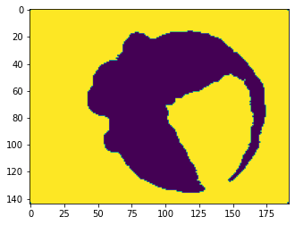

```python
plot_bin_slice(20, 119, 2, 0)
```

```python
def rle_decode(mask_rle, shape):
    '''
    mask_rle: run-length as string formatted (start length)
    shape: (height, width) of array to return
    Returns numpy array of shape (height, width) where 1 represents the mask
    '''
    s = list(map(int, mask_rle.split()))
    starts, lengths = s[0::2], s[1::2]
    starts = np.asarray(starts) - 1
    ends = starts + lengths
    img = np.zeros(shape[0] * shape[1], dtype=np.uint8)
    for start, end in zip(starts, ends):
        img[start:end] = 1
    return img.reshape(shape)
```

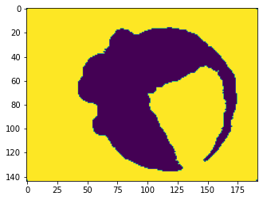

```python
img = rle_decode(code, (144, 192))
plt.imshow(img)
```

## Rendu

Mon modèle a un DICE de 0,9768 ce qui indique une erreur inférieure à 0,024. Aussi je l'utilise comme référence et si vos résultats sont à moins de 0,025 des miens, alors vous avez 20/20.

Attention, la qualité des résultat chute très vite car une grosse partie du succès est due à l'arrière plan qui est facile à détecter.

Regardez vos images, vous aurez une bonne impression de la qualité de vos résultats.

Voici les coupes qui sont utilisées pour la compétition :

```python
layers = [[102,  77,  49,  82],
          [ 54, 157,  35, 156],
          [149, 110, 181,  86]]
```

Je stocke mes prédictions pour les coupes demandées :

```python
res = []
i = 0
for sub in range(11, 23):   # je ne prends pas le dernier sujet (vous ne l'avez pas)
    for axis in range(3):
        for layer in layers[axis]:
            for material in range(4):
                img = brain[f"subject-{sub}"].take(layer, axis=axis)
                rle = rle_encoding(img[...,material])
                res.append(f"i{i}, {img.shape[0]}, {img.shape[1]}, {rle}")
                i += 1
len(res)
```

```
576
```

```python
res[4][:10]
```

```
'i4, 192, 2'
```

Et je construis le fichier CSV à soumettre à la compétion :

```python
with open(data_name+'.csv', 'w') as fichier:
    fichier.write("Id, Height, Width, RLE\n")
    for l in res:
        fichier.write(l + '\n')
```